# Detekcja samolotów ze zdjęć satelitarnych z użyciem modelu YOLOv8

Author

Patryk Tokarski

### Dane

#### Zbiór danych

Zbiór danych składa się z 3821 zdjęć satelitarnych, na których znajduje się 20 typów samolotów. W zbiorze jest 22341 oznaczonych obiektów. Zbiór danych pozyskałem z platformy Kaggle. Zdjęcia są w formacie jpg, a etykiety w formacie XML (PascalVOC). Zdjęcia są różnych rozmiarów, ale zazwyczaj mają rozmiar 800x800 pikseli.

#### Przykładowe zdjęcie ze zbioru danych

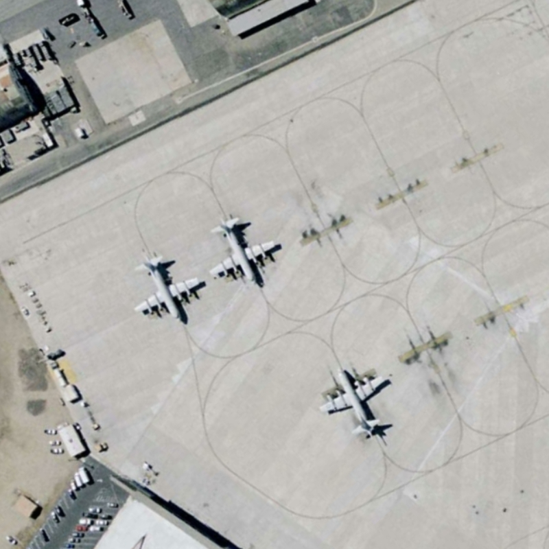

#### Etykiety

Oznaczenia klas samolotów w zbiorze danych nie są równomierne. Najwięcej samolotów należy do klasy A16, a najmniej do klasy A18. Poniżej przedstawiam rozkład klas samolotów w zbiorze danych.

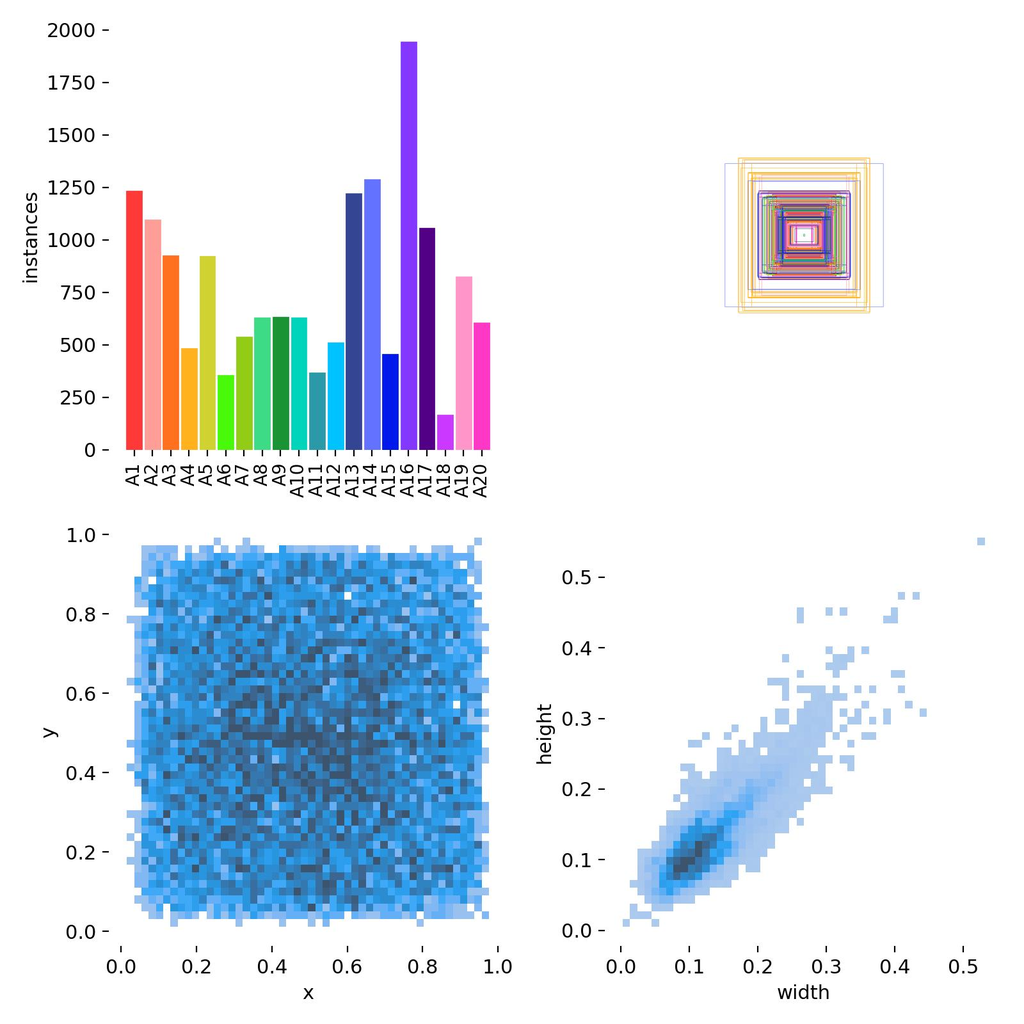

Samoloty na zdjęciach są ułożone równomiernie po całej wielkości zdjęć. Natomiast rozkłady szerokości i wysokości prostokątów, zawierających samoloty są lekko prawostronnie skośne.

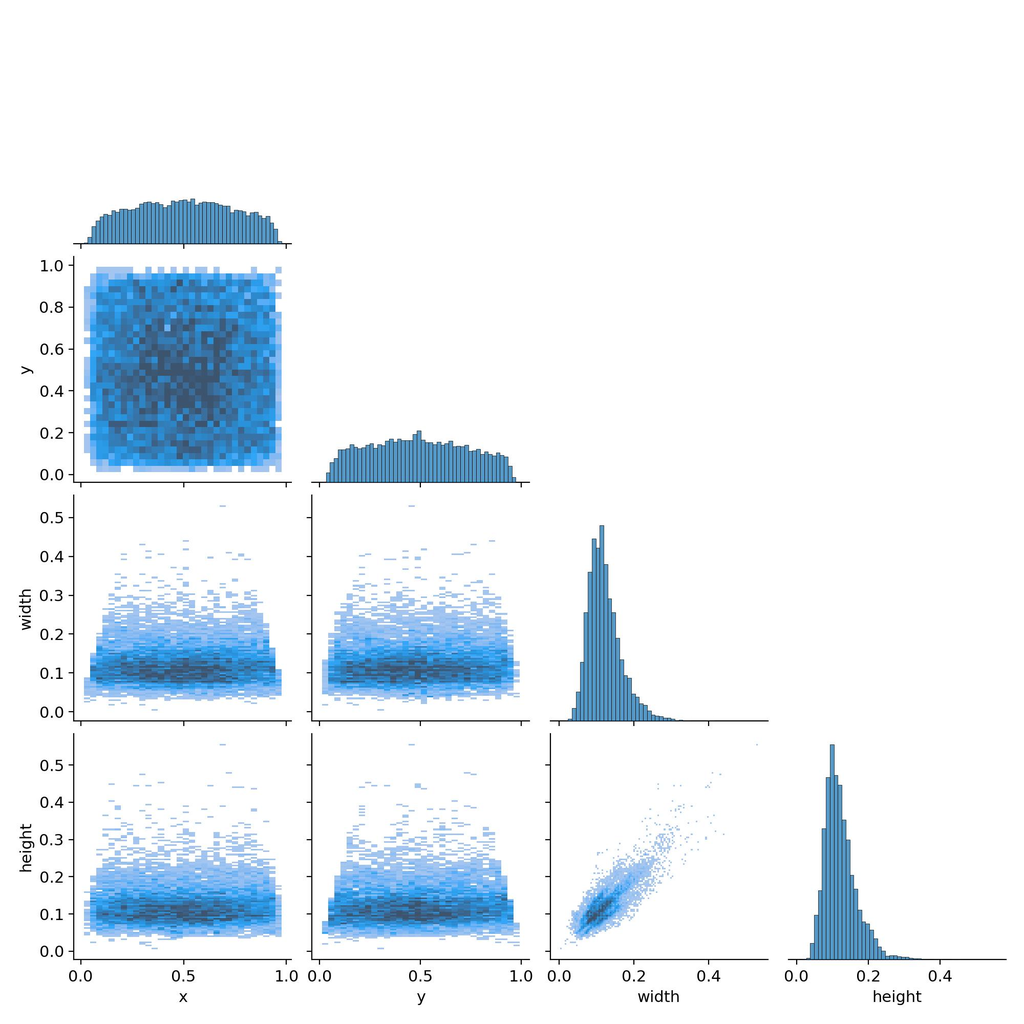

#### Przygotowanie

W pierwotnym zbiorze był podział tylko na zbiór uczący i testowy. W celu przeprowadzenia treningu modelu YOLO na zbiorze danych, z części zbioru treningowego utworzyłem zbiór walidacyjny.

Koniecznym krokiem było także przekonwertowanie etykiet z formatu XML (PascalVOC) na format txt (stosowany w YOLO). W tym celu napisałem krótki skrypt w Pythonie, który przekształca etykiety z formatu XML na format txt (skrypt znajduje się na końcu raportu).

W celu przeprowadzenia treningu modelu YOLO na nowym zbiorze danych, musiałem także przygotować plik data.yaml, który zawiera informacje o lokalizacji danych, plików z podziałami danych oraz etykietach. Zbiór danych składa się z 20 klas: A1, A2, A3, …, A20.

Gdy miałem już przygotowany zbiór danych, mogłem przystąpić do wyboru modeli, a następnie treningów modeli YOLO. W tym celu skorzystałem z biblioteki `ultralytics`, która ułatwia dotrenowywanie modelu YOLO na nowym zbiorze danych.

Trening modelu YOLO przeprowadziłem na platformie Kaggle, ponieważ mój komputer nie był w stanie przeprowadzić go w rozsądnym czasie (czas trwania jednego epoch’a wynosił 20 minut :) ).

### Modele

W ramach projektu postanowiłem wybrać dwa modele w dwóch wariantach: z zamrożeniem warstw i bez zamrożenia warstw. Modele, które wybrałem to:

- YOLOv8n
- YOLOv8m

v8m jest zdecydowanie większym modelem od v8n (różnica to prawie 23 miliony parametrów). Pozwoli mi to sprawdzić, czy większy model będzie w stanie lepiej nauczyć się zbioru danych. Zamrażanie warstw pozwoli mi na szybsze trenowanie modelu, ale może skutkować gorszymi wynikami.

### Metryki

Przy podsumowywaniu modeli kierowałem się dwoma metrykami: mAP50 i mAP50-95.

mAP50 mierzy skuteczność detekcji dla dopasowań, których poziom nałożenia się oryginalnej etykiety, a etykiety przewidzianej przez model wynosi co najmniej 50%. Natomiast mAP50-95 ocenia model w sposób bardziej szczegółowy i kompleksowy, uwzględniając różne poziomy dokładności dopasowania. Te metryki są domyślnie wyświetlanie przy treningu modeli YOLOv8.

### Trening i test modeli - schemat

Wszystkie modele trenowane były przez 100 epok, na platformie Kaggle, używając dodatkowo karty graficznej P100. Rozmiar obrazu wynosił 640x640. Resztę parametrów pozostawiłem domyślnych, tak aby program wybrał je sam.

Po wczytaniu bazowego modelu, douczamy model funkcją `train`, a następnie testujemy funkcją `val` podając odpowiedni split zadeklarowany w pliku data.yaml.

```python
from ultralytics import YOLO

model = YOLO('<nazwa_modelu>')

#trening
train = model.train(data='/kaggle/input/planesdataset/data.yaml', epochs=100, imgsz=640, verbose = False, device=0) # w niektórych przypadkach dodatkowo freeze=<ilość_warstw_do_zamrożenia>

#test
check = model.val(data='/kaggle/input/planesdataset/data.yaml', split='test', imgsz=640, verbose = False)
```

Aby dokonać predykcji modelu należy użyć funkcji `predict`

```python
model.predict('<path_to_image>', save=True)
```

#### Trening modelu yolov8n.pt

```python
from ultralytics import YOLO

model1 = YOLO('yolov8n.pt')
train = model1.train(data='/kaggle/input/planesdataset/data.yaml', epochs=100, imgsz=640, verbose = False, device=0)
```

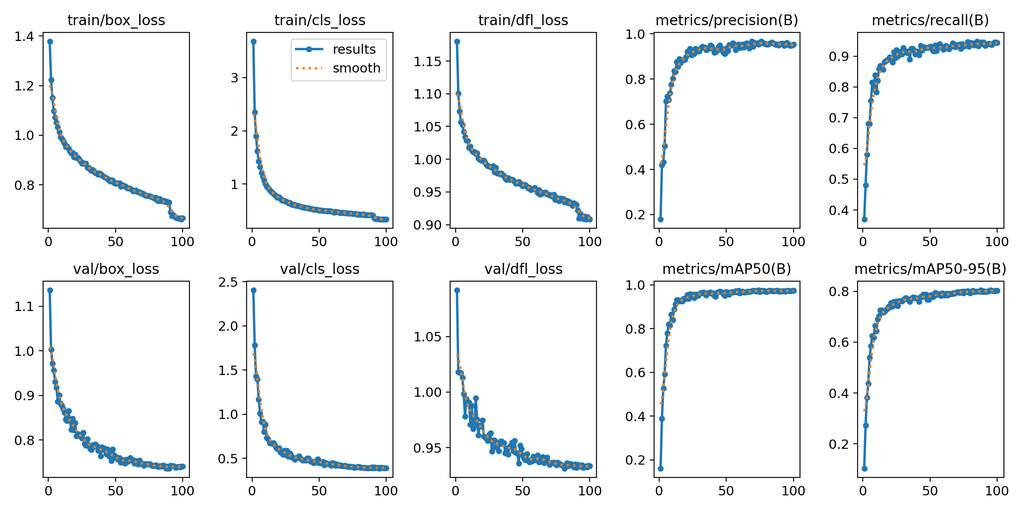

Znormalizowana confusion matrix dla zbioru testowego.

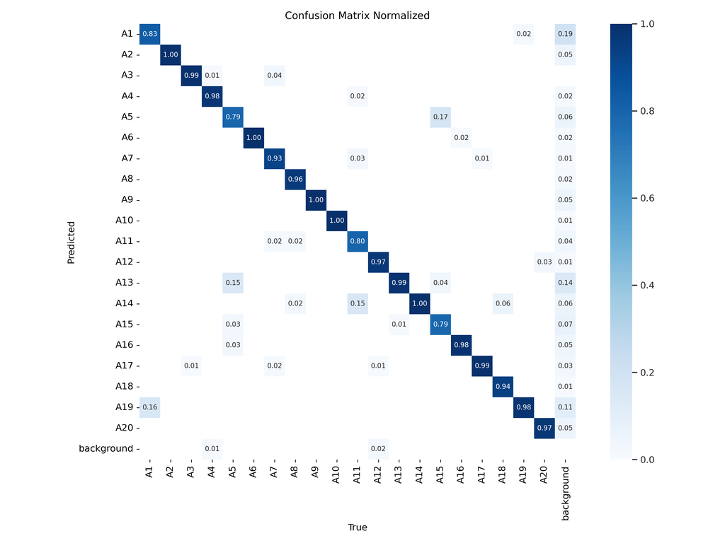

Cztery przykładowe predykcje na zbiorze testowym:

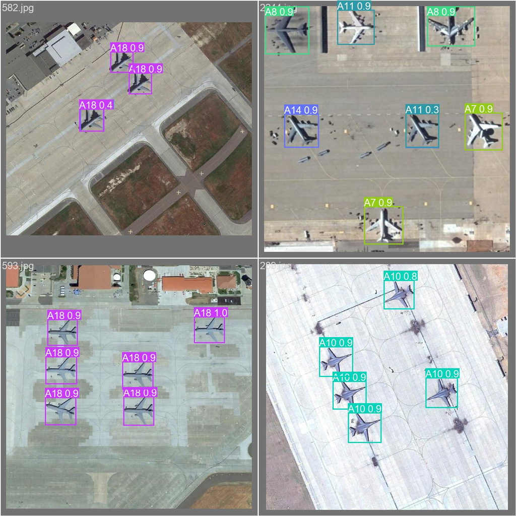

predykcja

#### Trening modelu yolov8n.pt z zamrożeniem 9 z 22 głównych warstw

```python
from ultralytics import YOLO

model1 = YOLO('yolov8n.pt')
train2 = model2.train(data='/kaggle/input/planesdataset/data.yaml', epochs=100, imgsz=640, verbose = False, device=0, freeze=9, cache=True)
```

Trening trwał 0,717h. W trakcie treningu model osiągnął mAP50 na zbiorze walidacyjnym na poziomie 0.887. Na zbiorze testowym model osiągnął mAP50 na poziomie 0.909 i mAP50-95 równe 0.698.

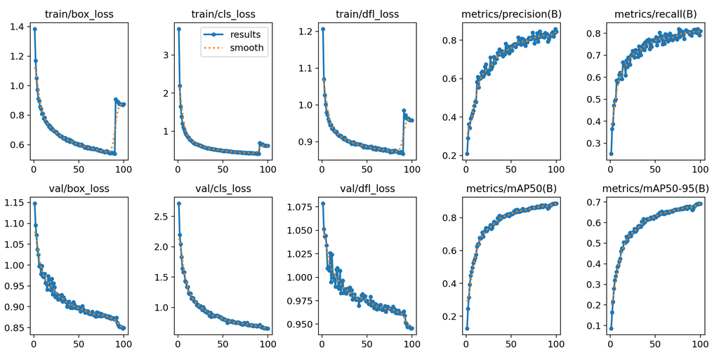

Znormalizowana confusion matrix dla zbioru testowego.

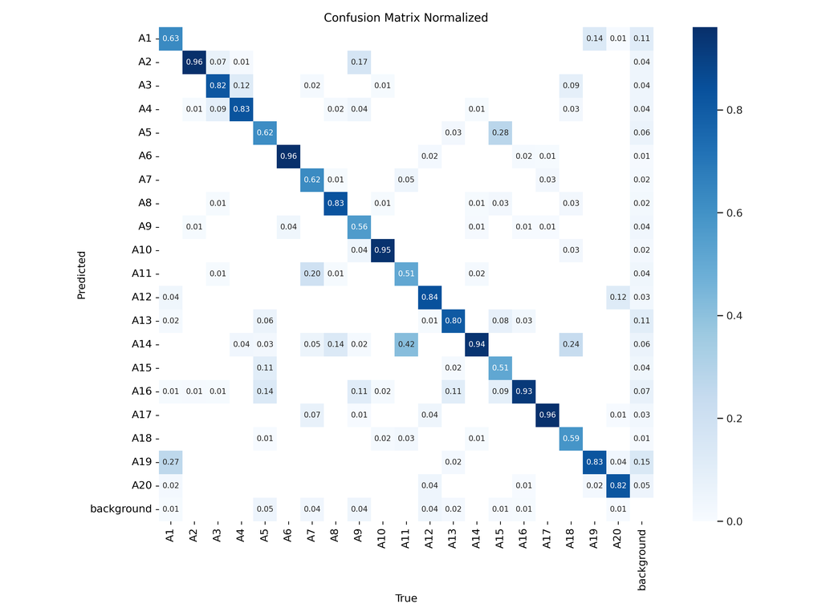

Cztery przykładowe predykcje na zbiorze testowym:

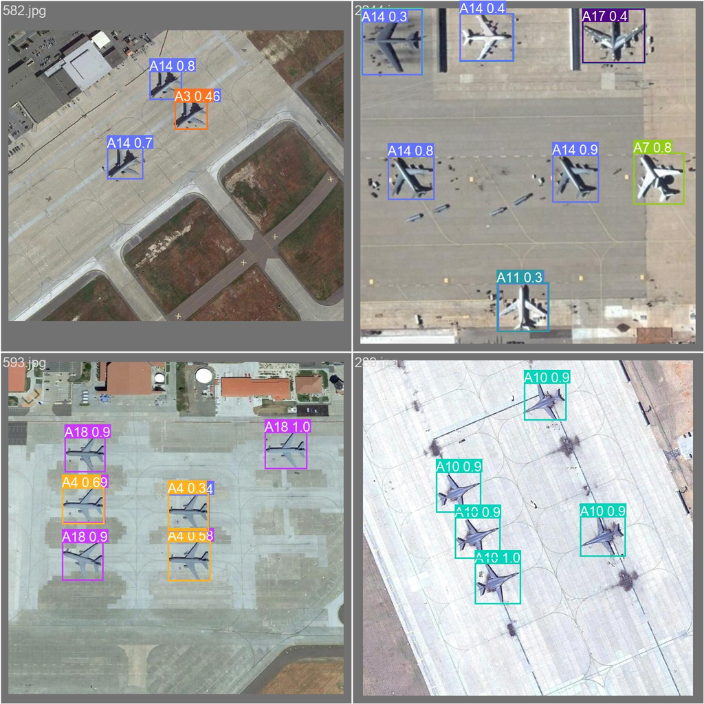

predykcja

#### Trening modelu yolov8m.pt

```python
from ultralytics import YOLO

model1 = YOLO('yolov8m.pt')
train1 = model1.train(data='/kaggle/input/planesdataset/data.yaml', epochs=100, imgsz=640, verbose = False, device=0, cache=True)
```

Trening trwał 3,125h. W trakcie treningu model osiągnął mAP50 na zbiorze walidacyjnym na poziomie 0.981. Na zbiorze testowym model osiągnął mAP50 na poziomie 0.981 i mAP50-95 równe 0.814.

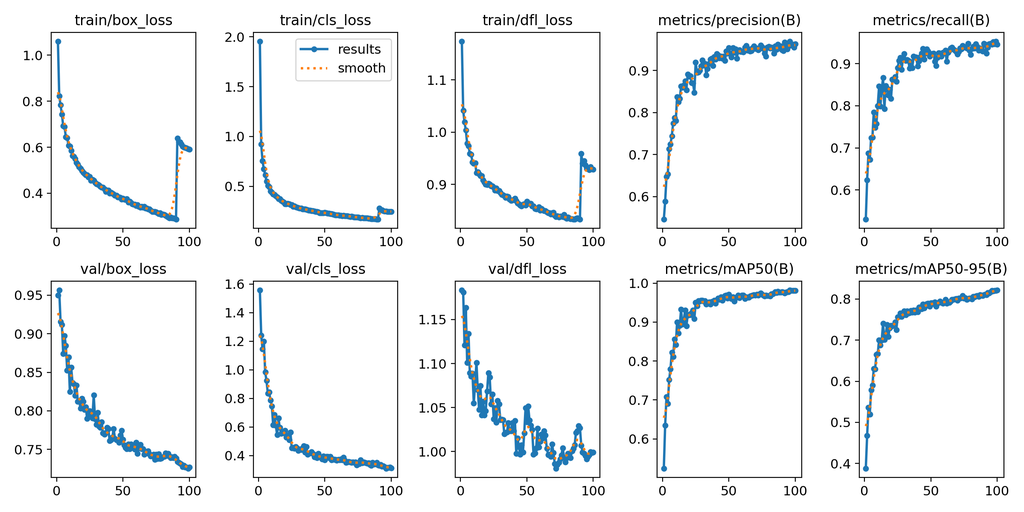

Znormalizowana confusion matrix dla zbioru testowego.

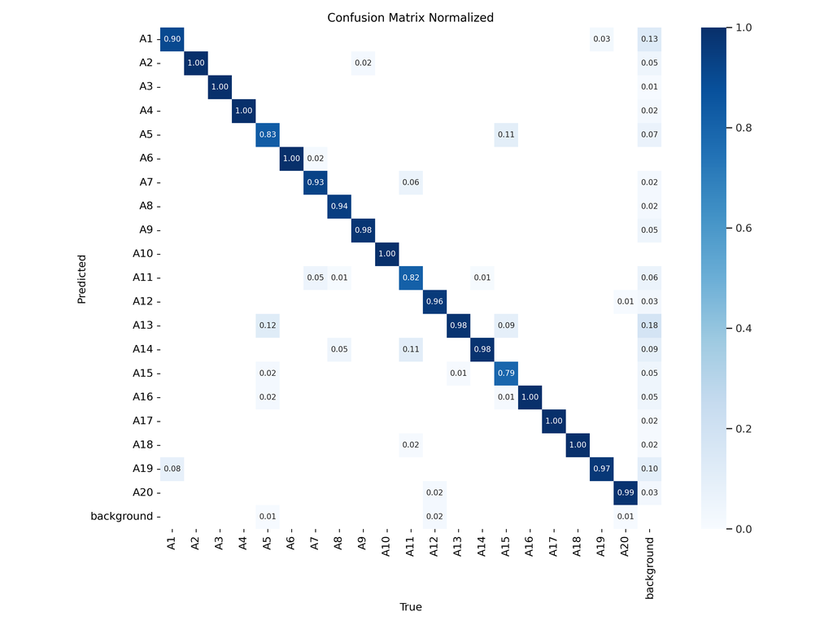

Cztery przykładowe predykcje na zbiorze testowym:

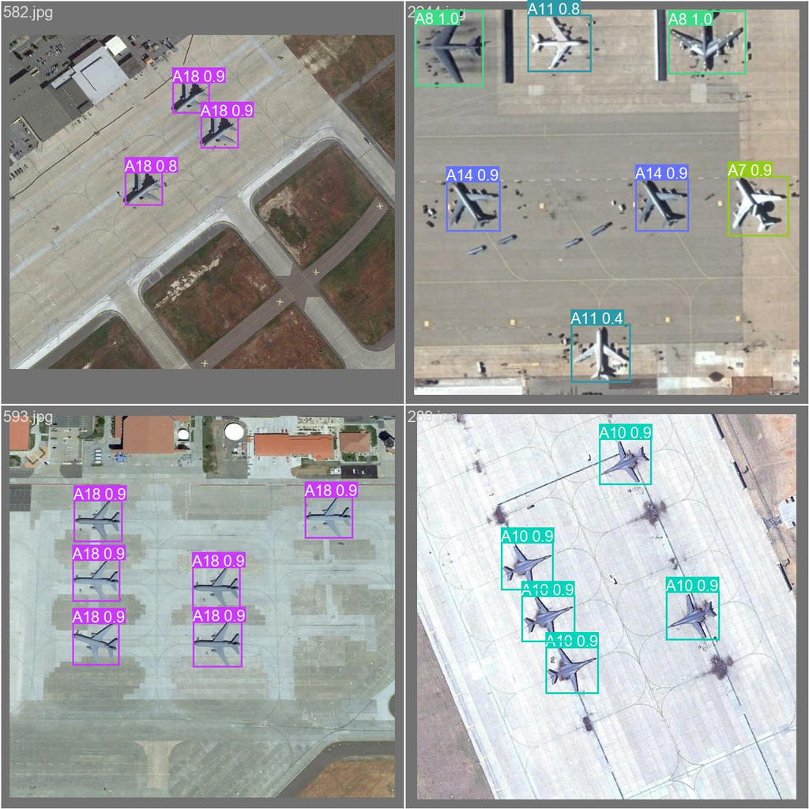

predykcja

#### Trening modelu yolov8m.pt z zamrożeniem 9 z 22 głównych warstw

```python
from ultralytics import YOLO

model1 = YOLO('yolov8m.pt')
train1 = model1.train(data='/kaggle/input/planesdataset/data.yaml', epochs=100, imgsz=640, verbose = False, device=0, cache=True, freeze=9)
```

Trening trwał 1,862h. W trakcie treningu model osiągnął mAP50 na zbiorze walidacyjnym na poziomie 0.963. Na zbiorze testowym model osiągnął mAP50 na poziomie 0.965 i mAP50-95 równe 0.784.

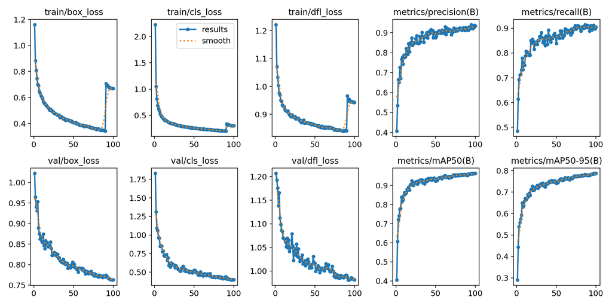

Znormalizowana confusion matrix dla zbioru testowego.

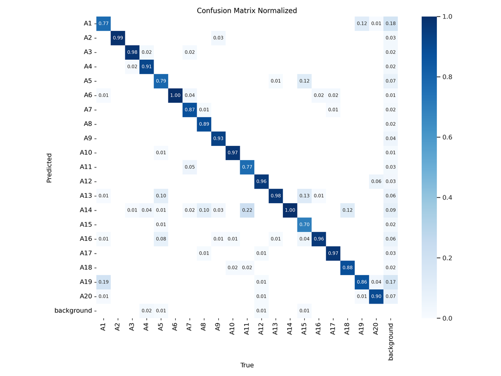

Cztery przykładowe predykcje na zbiorze testowym:

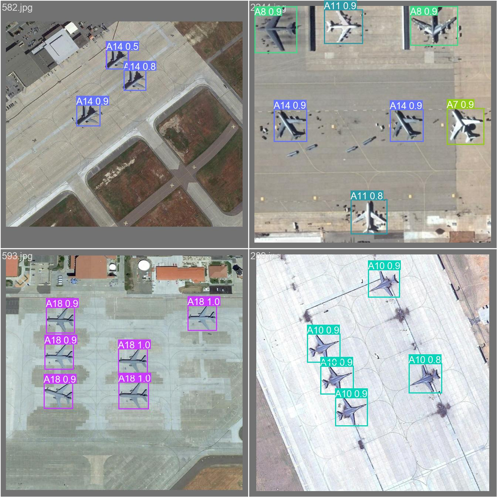

predykcja

### Wyniki

#### Tabelka

| Model | GFLOPs | Parametrów | Czas treningu | mAP50 (test) | mAP50-95 (test) |
| --- | --- | --- | --- | --- | --- |
| YOLOv8n | 8.215 | 3 014 748 | 1.178h | 0.98 | 0.8 |
| YOLOv8n + freeze | 8.215 | 3 014 748 | 0.717h | 0.91 | 0.698 |
| YOLOv8m | 79.127 | 25 867 900 | 3.125h | 0.981 | 0.814 |
| YOLOv8m + freeze | 79.127 | 25 867 900 | 1.862 | 0.965 | 0.784 |

#### Wnioski

Model YOLOv8n wypadł moim zdaniem najlepiej. Jego trening trwał lekko powyżej godziny, a wyniki jakie osiągał prawie dorównywały modelowi v8m ze zdecydowanie większą ilością parametrów.

Modele, w których początkowe warstwy były zamrażane, znacznie szybciej osiągały 100 epoch. Jednak ich wyniki odstawały od zwykłych modeli.

Model YOLOv8m osiągnął najlepsze wyniki, jednak jego trening trwał ponad 3 godziny. Być może gdyby w zbiorze danych było więcej zdjęć, różnice między modelami byłyby bardziej zauważalne.

### Źródła

Zbiór danych: [Kaggle Military Aircraft Recognition dataset](https://www.kaggle.com/datasets/khlaifiabilel/military-aircraft-recognition-dataset/data)

Oficjalna dokumentacja pakietu `ultralytics`: https://docs.ultralytics.com/

W szczególności:

- [Trening modelu](https://docs.ultralytics.com/modes/train/)
- [Walidacja modelu](https://docs.ultralytics.com/modes/val/)
- [Predykcja modelu](https://docs.ultralytics.com/modes/predict)
- [Metryki w modelu YOLO](https://docs.ultralytics.com/guides/yolo-performance-metrics/)

#### Skrypt do konwersji etykiet z formatu VOC (xml) do formatu YOLO (txt)

```python
import os
import xml.etree.ElementTree as ET

def parse_xml_to_txt(xml_file, txt_file):
  tree = ET.parse(xml_file)
  root = tree.getroot()

  with open(txt_file, 'w') as f:
    width_img = int(root.find('size').find('width').text)
    height_img = int(root.find('size').find('height').text)
    if width_img == 0 or height_img == 0:
      print(f"Invalid image size in {xml_file}")
      return

    for obj in root.findall('object'):
      name = obj.find('name').text
      if name.startswith('A') and name[1:].isdigit():
        name_num = name[1:]
        name_num = int(name_num)-1
        bndbox = obj.find('bndbox')
        xmin = bndbox.find('xmin').text
        ymin = bndbox.find('ymin').text
        xmax = bndbox.find('xmax').text
        ymax = bndbox.find('ymax').text

        width = int(xmax) - int(xmin)
        height = int(ymax) - int(ymin)
        x_center = (int(xmin) + int(xmax)) / 2
        y_center = (int(ymin) + int(ymax)) / 2


        f.write(f"{name_num} {x_center/width_img} {y_center/height_img} {width/width_img} {height/height_img}\n")

lista = os.listdir('PlanesDataset\\Annotations')
for xml_file in lista:
    xml_file = os.path.join('PlanesDataset\\Annotations', xml_file)
    txt_file = xml_file.replace('.xml', '.txt').replace('Annotations', 'labels')
    parse_xml_to_txt(xml_file, txt_file)
```